# GDP @ Risk

Andrew P Blake

October 2020

> *The Bank of England does not accept any liability for misleading or inaccurate information or omissions in the information provided. The subject matter reflects the views of the individual presenter and not the wider Bank of England or its Policy Committees.*

## Simple implementation of *GDP at Risk* using R

A somewhat fashionable use of quantile regression is by Adrian, Boyarchenko, and Giannone (2019), and their idea has become known as *GDP-at-risk*, rather like VaR. The idea is to use a simple forecasting model that uses some financial indicator and find the “at risk” value of growth. There are three elements:

- Estimate a “forecasting model” using quantile regression that depends on some forward-looking indicator.
- Fit a skew Student-t model to the output of their quantile estimation procedure, and use this to find the “at risk” value.
- We will plot the result as a *ridgeline graph*, which are really quite cool.

This is computationally quite a bit harder than our other applications.

## Prelims

We need a lot of libraries for this one, although we have relatively little code!

```r
library(jsonlite)          # Read in UK data
library(zoo)               # Date stuff
library(quantreg)          # Quantile regression
library(ggridges)          # Ridgeline plots
library(viridis)           # Colours for graphs
library(fitdistrplus)      # Package to fit parametric distributions
library(sn)                # Skew-t distribution
library(tidyverse)         # Usual
library(lubridate)         # More usual
library(readxl)            # And more...
```

## Data

Downloaded data *up until 2018* for [UK GDP growth](https://www.ons.gov.uk/economy/grossdomesticproductgdp/timeseries/ihyr) in [JSON format](https://www.ons.gov.uk/economy/grossdomesticproductgdp/timeseries/ihyr/data) from ONS UK in a file called `ihyr.json`.

```r
json  <- fromJSON("ihyr.json")  # Use jsonlite to parse file

# Retrieve quarterly data, dates etc and calculate lags
qdata <- json$quarters %>%
  mutate(Date   = as.Date(as.yearqtr(date, format = "%Y Q%q")),
         Growth = as.numeric(value)) %>%
  select(Date, Growth) %>%
  mutate(Growth_1 = lag(Growth, 1),
         Growth_4 = lag(Growth, 4)) %>%
  drop_na()
```

[BIS credit data](https://www.bis.org/statistics/totcredit.htm) is available [here](https://www.bis.org/statistics/totcredit/totcredit.xlsx) – be warned there is a lot of it, and you need to get all of it to find the bits you want.

```r
totcredit <- read_excel("totcredit.xlsx",
                        sheet = "Quarterly Series",
                        col_types = c("date", rep("text", 1130))) %>%
  select(Date = "Back to menu", starts_with("United K")) %>%            # Find UK
  slice(-c(1:3)) %>%
  select(-contains("US Dollar"), -contains("Unadjusted"), -contains("Domestic currency")) %>%
  mutate(Date = as.Date(Date))
```

```
## Warning in read_fun(path = enc2native(normalizePath(path)), sheet_i = sheet, :
## Expecting date in A4 / R4C1: got 'Period'
```

Names in the BIS file are very long so kludge them to something a bit more readable.

```r
nn  <- gsub("United Kingdom - ", "", names(totcredit))
nn  <- gsub(" - Adjusted for breaks", "", nn)
nn  <- gsub(" - Percentage of GDP", "", nn)
nn  <- gsub(" at Market value", "", nn)

totcredit <- rename_with(totcredit, ~ nn)
```

### Plots of pivoted data

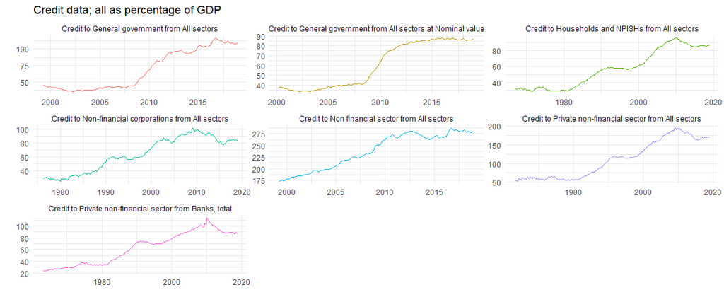

```r
dd <- totcredit %>%
  pivot_longer(cols=-Date, names_to = "Var", values_to = "Val") %>%
  mutate(Val = as.numeric(Val)) %>%
  filter(!is.na(Val))

ggplot(dd) +
  geom_line(aes(x=Date, y=Val, group=Var, colour=Var), show.legend = FALSE) +
  facet_wrap(~Var, scales = "free") +
  theme_minimal() +
  labs(x="", y="", title="Credit data; all as percentage of GDP")
```

### Difference data at required interval

We will use some measure of long run credit growth as a predictor of financial fragility. Pick an interval – we choose five years – and calculate the growth rate.

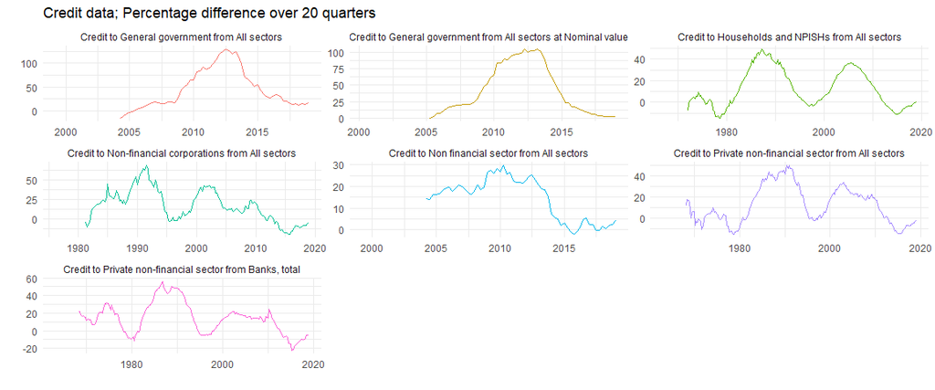

```r
lagv <- 20

dd2 <- dd %>%
  group_by(Var) %>%
  mutate(Val = 100*(Val/lag(Val,lagv)-1)) %>%
  ungroup()

ggplot(dd2) +
  geom_line(aes(x=Date, y=Val, group=Var, colour=Var), show.legend = FALSE) +
  facet_wrap(~Var, scales = "free") +
  theme_minimal() +
  labs(x="",y="", title=paste("Credit data; Percentage difference over", lagv, "quarters"))
```

### Choose a variable

We select the variable we want, plot it to check, and then create a data set to use in the quantile regression. What are the variables?

```r
# Recall all the names are in nn
print(nn)
```

```
## [1] "Date"
## [2] "Credit to Non financial sector from All sectors"
## [3] "Credit to General government from All sectors"
## [4] "Credit to General government from All sectors at Nominal value"
## [5] "Credit to Households and NPISHs from All sectors"
## [6] "Credit to Non-financial corporations from All sectors"
## [7] "Credit to Private non-financial sector from All sectors"
## [8] "Credit to Private non-financial sector from Banks, total"
```

Let’s go for number 7.

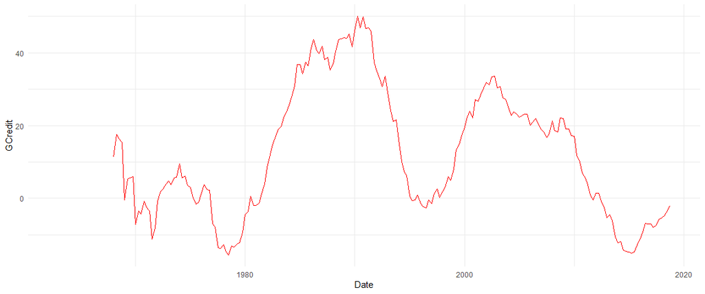

```r
dd2a <- filter(dd2, Var == nn[7]) %>%
  select(Date, Val) %>%
  rename_with(~ c("Date", "GCredit")) %>%
  mutate(Date = floor_date(Date, unit="quarter")) %>%
  arrange(Date)

# Quick plot to check we have the right one
ggplot(dd2a) +
  geom_line(aes(x=Date, y=GCredit), color = "red") +
  theme_minimal()
```

```r
dataz <- left_join(qdata, dd2a, by="Date") %>%
  mutate(GCredit_1 = lag(GCredit,1)) %>%
  mutate(GCredit_4 = lag(GCredit,4)) %>%
  drop_na()

head(dataz)
```

```
##         Date Growth Growth_1 Growth_4    GCredit  GCredit_1  GCredit_4
## 1 1969-01-01    1.7      5.7      6.1 -0.5033557 15.2963671 11.2727273
## 2 1969-04-01    2.9      1.7      4.2  5.3173242 -0.5033557 17.4953959
## 3 1969-07-01    1.5      2.9      5.8  5.6042032  5.3173242 16.4485981
## 4 1969-10-01    1.6      1.5      5.7  5.9033989  5.6042032 15.2963671
## 5 1970-01-01    1.2      1.6      1.7 -7.2231140  5.9033989 -0.5033557
## 6 1970-04-01    2.8      1.2      2.9 -3.4257749 -7.2231140  5.3173242
```

## Equation and estimates

Run a single quantile regression. We will do just one, and then look at in-sample predictions. Really we ought to do this recursively. A couple of parameters let us choose bits of the model.

```r
fcast <- 4
inccg <- 1

if (inccg > 0) {
  eqn.q <- formula(paste0("Growth ~ Growth_", fcast, " + GCredit_", fcast))
} else {
  eqn.q <- formula(paste0("Growth ~ Growth_", fcast))
}

q.inst <- rq(eqn.q, data=dataz, tau=seq(.05,.95,.025))
summary(q.inst)
```

```
##
## Call: rq(formula = eqn.q, tau = seq(0.05, 0.95, 0.025), data = dataz)
##
## tau: [1] 0.05
##
## Coefficients:
##             coefficients lower bd upper bd
## (Intercept) -2.89534     -4.02036 -1.78902
## Growth_4    -0.09964     -0.13240  0.13738
## GCredit_4    0.04087     -0.09931  0.05583
##
## Call: rq(formula = eqn.q, tau = seq(0.05, 0.95, 0.025), data = dataz)
##
## tau: [1] 0.075
##
## Coefficients:
##             coefficients lower bd upper bd
## (Intercept) -1.78578     -3.36345 -0.93441
## Growth_4    -0.00358     -0.17026  0.51722
## GCredit_4    0.01678     -0.01505  0.05030
##
## Call: rq(formula = eqn.q, tau = seq(0.05, 0.95, 0.025), data = dataz)
##
## tau: [1] 0.1
##
## Coefficients:
##             coefficients lower bd upper bd
## (Intercept) -0.08552     -2.66013  0.59685
## Growth_4     0.25720     -0.19695  0.36729
## GCredit_4   -0.01080     -0.04173  0.03887
##
## Call: rq(formula = eqn.q, tau = seq(0.05, 0.95, 0.025), data = dataz)
##
## tau: [1] 0.125
##
## Coefficients:
##             coefficients lower bd upper bd
## (Intercept)  0.58423     -1.39031  0.78957
## Growth_4     0.23998      0.15733  0.34964
## GCredit_4   -0.02636     -0.03981  0.00141
```

[output cut: 315 more lines]

```
## Coefficients:
##             coefficients lower bd upper bd
## (Intercept)  3.80496      3.52365  4.70159
## Growth_4     0.39910      0.02449  0.44017
## GCredit_4    0.01204     -0.02732  0.03214
##
## Call: rq(formula = eqn.q, tau = seq(0.05, 0.95, 0.025), data = dataz)
##
## tau: [1] 0.95
##
## Coefficients:
##             coefficients lower bd upper bd
## (Intercept)  4.64977      3.88400  5.01784
## Growth_4     0.31752      0.05000  0.47997
## GCredit_4    0.00122     -0.00562  0.03794
```

## Non-parametric results

We can easily plot the interpolated empirical density as ridgeline plots, see Wilke (2020). First we retrieve and then organize the predicted values.

```r
q.predict <- t(predict(q.inst)) %>%           # In-sample predictions
  as_tibble(.name_repair = "unique") %>%
  rename_with(~ as.character(dataz$Date)) %>%
  pivot_longer(everything(), names_to = "Date", values_to = "Vals") %>%
  mutate(Date = as.Date(Date)) %>%
  filter(lubridate::year(Date) > 1003)
```

Next we plot them as non-parametric density estimates in a ridgeline plot.

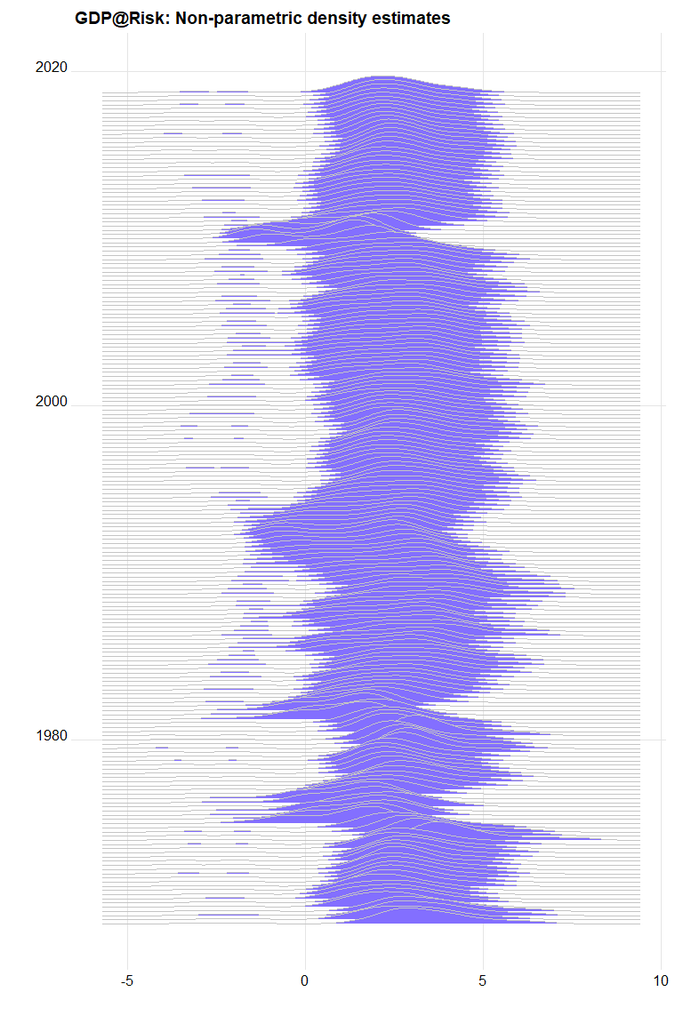

```r
ggplot(q.predict, aes(x=Vals, y=Date, group=Date)) +
  geom_density_ridges(scale=5, colour="grey77", fill="slateblue1") +
  theme_ridges() +
  labs(x="", y="", title = "GDP@Risk: Non-parametric density estimates")
```

What about with the tail probabilities emphasized? Now we need to use `stat_density_ridges` instead of the `geom`, and it takes a long time to plot, as the fill is over the continuous x-axis.

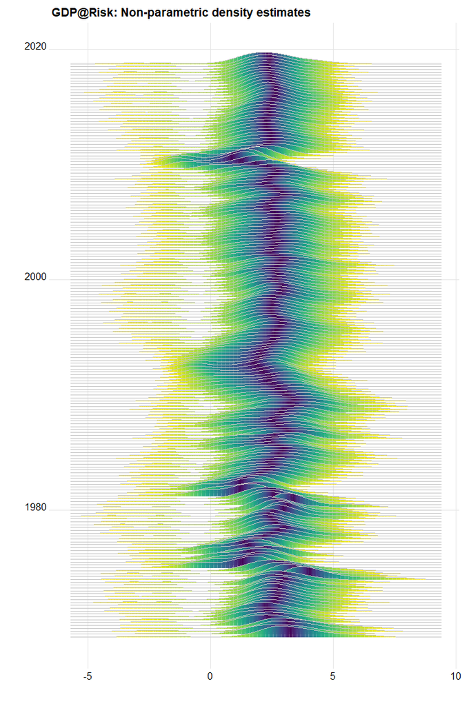

```r
ggplot(q.predict, aes(x=Vals, y=Date, group=Date, fill = 0.5-abs(0.5-stat(ecdf)))) +
  stat_density_ridges(geom="density_ridges_gradient", calc_ecdf=TRUE, scale=5, colour="grey77") +
  scale_fill_viridis(option="D", direction=-1, alpha=.7) +
  theme_ridges() +
  theme(legend.position = "none") +
  labs(x="", y="", title = "GDP@Risk: Non-parametric density estimates")
```

There’s quite a long, messy left hand tail, and the density is often bi-modal. A way of tidying this up is to fit a parametric distribution to this, and then treating that as the actual distribution.

### Parametric results

We now fit a skew-t to the predicted quantiles, and then work with these estimated densities afterwards.

```r
dens <- NULL # Store densities
val5 <- NULL # Store 5% info
eall <- NULL # Store estimated parameters

x   <- seq(-5,7,0.05)                        # Evaluate fitted density over this interval

st  <- list(xi=2, omega=1, alpha=0, tau=0)
for (i in unique(q.predict$Date)) {

  pp  <- filter(q.predict, Date==i)                             # Predicted vals for i

  fsn <- fitdist(pp$Vals, "sn", method="mge", start=st)         # Fit the skew t
  e   <- fsn$estimate                                           # Fitted values
  y   <- dsn(x,    xi=e[1], omega=e[2], alpha=e[3], tau=e[4])   # Fitted density
  vr  <- qsn(0.05, xi=e[1], omega=e[2], alpha=e[3], tau=e[4])   # 5% quantile
  dr  <- dsn(vr,   xi=e[1], omega=e[2], alpha=e[3], tau=e[4])   # Density at that point

  dens <- bind_rows(dens, tibble(x=x,   y=y,   Date=i))
  val5 <- bind_rows(val5, tibble(vr=vr, dr=dr, Date=i))
  eall <- bind_rows(eall, tibble(Date=as.Date(i), xi=e[1], omega=e[2], alpha=e[3], tau=e[4]))

}
```

Plots of calculated values and 5% boundary as dots

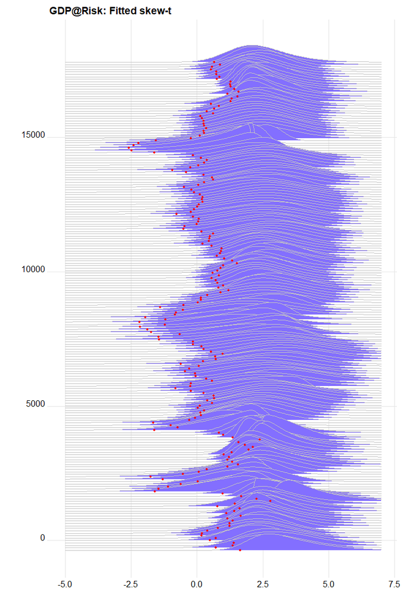

```r
sc   <- 1750                                    # Scale factor

#ggplot(dens) +
#  geom_ridgeline_gradient(aes(x=x, height=y, y=Date, group=Date, scale=sc, fill=..x..),
#                          colour="grey77") +
#  geom_point(data=val5, aes(x = vr, y = Date), color="red", size=1.1) +
#  scale_fill_viridis(name="Growth\ndistribution", option = "D", direction = -1, alpha=.7) +
#  theme_ridges() +
#  labs(x="", y="", title = "GDP@Risk: Fitted skew-t")

ggplot(dens) +
  geom_ridgeline(aes(x=x, height=y, y=Date, group=Date),
                 colour="grey77", fill="slateblue1", scale=sc) +
  geom_point(data=val5, aes(x = vr, y = Date), color="red", size=1.1) +
  theme_ridges() +
  labs(x="", y="", title = "GDP@Risk: Fitted skew-t")
```

We can use vertical lines the height of the density at these points which is handy – so this is a version of that where we have to redefine the “super y” axis.

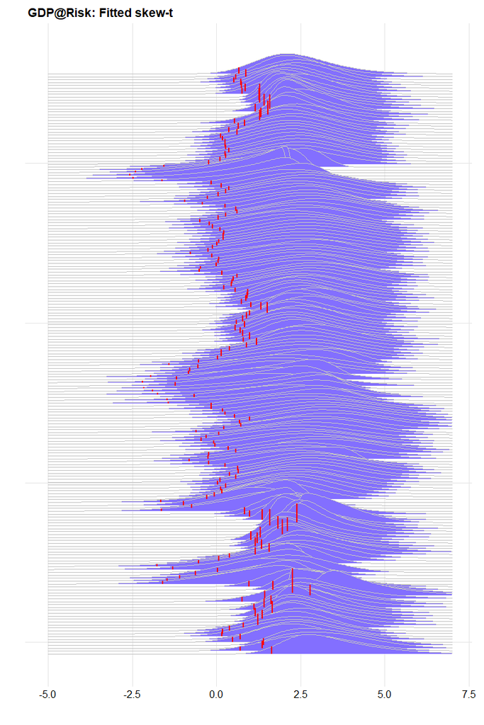

```r
dens <- mutate(dens, Datef=as.numeric(Date))    # Dates as numbers
val5 <- mutate(val5, Datef=as.numeric(Date))

ggplot(dens) +
  geom_ridgeline(aes(x=x, height=y, y=Datef, group=Date),
                 colour="grey77", fill="slateblue1", scale=sc) +
  geom_segment(data=val5, aes(x=vr, xend=vr, y=Datef, yend=Datef+sc*dr),
               color="red", size=0.75) +
  theme_ridges() +
  labs(x="", y="", title = "GDP@Risk: Fitted skew-t") +
  theme(axis.text.y = element_blank())
```

But notice we’ve changed how we deal with the observation indices to draw this so easily, and this means losing the date labels.

## References

Adrian, Tobias, Nina Boyarchenko, and Domenico Giannone. 2019. “Vulnerable Growth.” *American Economic Review* 109 (4): 1263–89.

Wilke, Claus O. 2020. *ggridges: Ridgeline Plots in ’ggplot2’*. https://CRAN.R-project.org/package=ggridges.